# Ford GoBike Data Exploration

### Talk about some of the relationships you observed in this part of the investigation. How did the feature(s) of interest vary with other features in the dataset?

During my bivariate exploration, I wanted to see how the `duration_sec`, `age`, and `distance` numerical variables would each reflectin the `user_type` and `member_gender` categorical variables. I plotted a stacked plot to provide some insight on how the two categorical variables related to each other. I noticed two important things here:

```
1. There are more members categorized as _Subscriber_ than as _Customer_.
2. The gender breakdown looks to be male dominant, suggesting that more riders who identified as male used the city-bike system for commuting
```

Even further than the second finding, it can be said (based on the data) that there were more Male Subscriber members than than all other demographic combinations combined, which I find very interesting, as I was hoping and had expected that it would as such, but not nearly as extreme as it looks.

I will now be diving into each categorical variable's bivariate explorations:

1. **User Type Variable** - *Faceted Plots*:

   A. When plotting the relationship between `user_type` and `duration_sec` I noticed that this specific relationship seems to be most parallel with the prior categorical variable stacked plot. You can see that more Subscriber members rented bikes than Customer members; however, the duration_sec of each trip isn't affected by the user type specifically. As you can see both user types have unimodal distubtions.

   B. When plotting the relationship between `user_type` and `age` I found a similar distribution between Subscriber and Customer members. It looks like the average age range for Subscriber members is somewhere in between 25-35 years old; whereas, the Customer members looks like the average age range is 30-40 years old. Again, both user types have unimodal plot shapes.

   C. When plotting the relationship between `user_type` and `distance` I noted that the relationship again was parallel to the stacked categorical plot. What I did notice was that Subscriber members seemed to have traveled further distances than Customer members. I can also see that both user type distibutions are unimodal as well.
1. **Member Gender Variable** - *Bar Plots*:

   A. When comparing `member_gender` with `duration_sec`, you can see that despite there being more male identifying members, members who identify as non-binary or chose not to identify at all ended up traveling the longest duration when it came to trips taken. With female members having trips with longer durations than male members as well.

   C. Finally when I plotted the relationship between `member_gender` and `distance` I found something specifically odd. Each gender category, as in, it didn't matter what each rider identified as in this case. This conclusion stems from the fact that each gender has traveled the same distances, or as close to the same distances as possible. Each bar looks equal to the last, and so do the standard deviations as well.

### Did you observe any interesting relationships between the other features (not the main feature(s) of interest)?

I did NOT observe anything specifically interesting outside of the main features unfortunately. I attribute this to having found a good deal of points of interest having explored the main features so thoroughly.

### Extra Bivariate Plotting

```python
trip['duration_sec'] = trip['duration_sec'].apply(pd.to_numeric)
trip['age'] = trip['age'].apply(pd.to_numeric)
trip['distance'] = trip['distance'].apply(pd.to_numeric)
```

```python
trip['duration_sec'] = trip['duration_sec'].replace(np.nan, 0.0)
trip['age'] = trip['age'].replace(np.nan, 0.0)
trip['distance'] = trip['distance'].replace(np.nan, 0.0)
```

```python
numeric_vars = ['duration_sec', 'age', 'distance']
categoric_vars = ['user_type', 'member_gender']
```

```python
def num_varGrid():
    samples = np.random.choice(trip.shape[0], 10000, replace = False)
    trip_samp = trip.reindex(columns = numeric_vars)

    g = sb.PairGrid(data = trip_samp, vars = numeric_vars)
    g = g.map_diag(plt.hist, bins = 20);
    g.map_offdiag(plt.scatter)
    replacements = {'duration_sec': 'Duration (sec)', 'age': 'Age',
                'duration_sec': 'Duration (sec)', 'age': 'Age',
                'distance': 'Distance (mi)', 'distance': 'Distance (mi)'}

    for i in range(3):
        for j in range(3):
            xlabel = g.axes[i][j].get_xlabel()
            ylabel = g.axes[i][j].get_ylabel()
            if xlabel in replacements.keys():
                g.axes[i][j].set_xlabel(replacements[xlabel])
            if ylabel in replacements.keys():
                g.axes[i][j].set_ylabel(replacements[ylabel])

    g.fig.suptitle('Numerical Variable Distribution', y = 1.04)
```

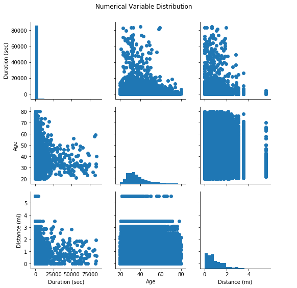

```python
num_varGrid()
```

You can see here, I wanted to show a grid of bivariate plots for each numerical variable against another. In the first column of plots you can see `duration_sec`'s relationship with its numerical variable group mates. The same for `age` and `distance`. This was to showcase a quick glimpse at what I've been exploring thus far numerically.

## Multivariate Exploration

```python
def encodingsplot1():
    plt.scatter(data = trip, x = 'duration_sec', y = 'distance',
                c = 'age')
    plt.colorbar(label = 'Age')
    plt.xlim(0, 75000)
    plt.ylim(0, 10)
```

```python
def encodingsplot2():
    plt.scatter(data = trip, x = 'age', y = 'duration_sec',
                c = 'distance')
    plt.colorbar(label = 'Distance')
    plt.xlim(0, 80)
    plt.ylim(0, 75000)
```

```python
def encodingsplot3():
    plt.scatter(data = trip, x = 'distance', y = 'age',
                c = 'duration_sec')
    plt.colorbar(label = 'Duration (sec)')
    plt.xlim(0, 10)
    plt.ylim(0, 80)
```

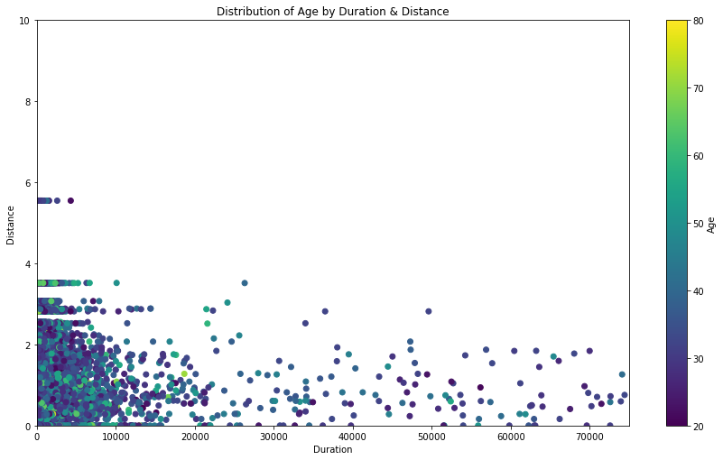

```python
myPlt("Distribution of Age by Duration & Distance", "Duration", "Distance");
encodingsplot1()
```

Here is a encoding plot of `age` distributed by `distance` and `duration_sec`. You can see that there is a wide spread betweent the max and min values for duration. However, you can see the crowded lower left corner of this plot. This means that most ages didn't travel long and didn't travel far.

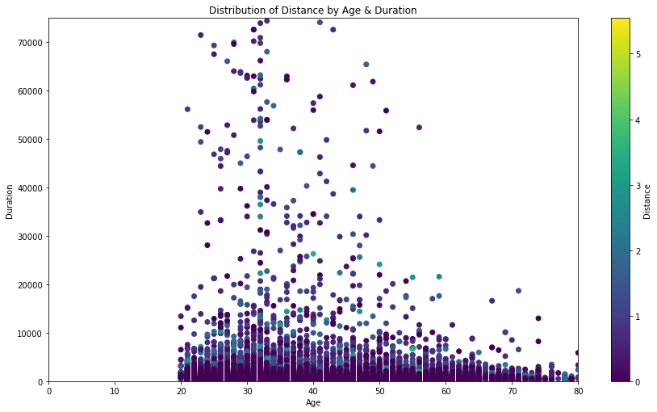

```python
myPlt("Distribution of Distance by Age & Duration", "Age", "Duration");
encodingsplot2()
```

You can see more of the same as the last plot here.

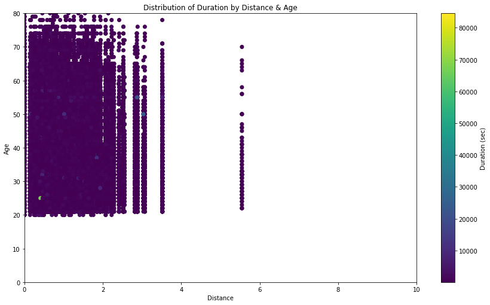

```python
myPlt("Distribution of Duration by Distance & Age", "Distance", "Age");
encodingsplot3()
```

Likewise with this plot, although this one is not nearly as helpful as the first plot.

```python
def violinplot():
    g = sb.PairGrid(data = trip, x_vars = ['duration_sec', 'age', 'distance'],
                    y_vars = ['user_type','member_gender'])
    g.map(sb.violinplot, inner = 'quartile')
    replacements = {'duration_sec' : 'Duration (sec)', 'age' : 'Age', 'distance' : 'Distance (mi)',
                    'user_type' : 'User Type', 'member_gender': 'Member Gender'}

    for i in range(2):
        for j in range(2):
            xlabel = g.axes[i][j].get_xlabel()
            ylabel = g.axes[i][j].get_ylabel()
            if xlabel in replacements.keys():
                g.axes[i][j].set_xlabel(replacements[xlabel])
            if ylabel in replacements.keys():
                g.axes[i][j].set_ylabel(replacements[ylabel])
    g.fig.suptitle('Violin Plot Grid', y = 1.04)
    g.tight_layout()
```

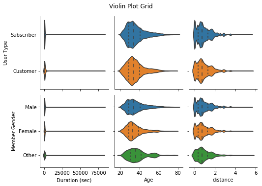

```python
violinplot()
```

As you can see this is the first time I've plotted all of the main features against each other. In the form of violin plots you can see each numerical variable plotted against each categorical variable. Here will also be the last time all of the variables are plotted together at once. As I believe I found a exploration route that I should take.

```python
def pinplot():
    sb.pointplot(data = trip, x = 'user_type', y = 'distance', hue = 'member_gender',
                  dodge = 0.3, linestyles = "")
```

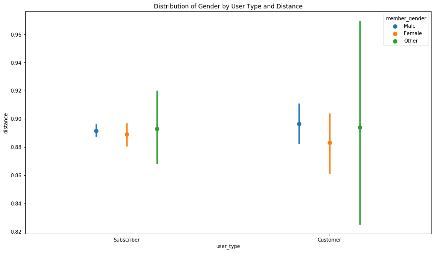

```python
myPlt("Distribution of Gender by User Type and Distance", "User Type", "Distance");
pinplot()
```

Here you can see how gender is represented in each user type and in distance traveled. Again you can see that the Other gender type has the widest range of distances traveled per trip. But now, there is another strange behavior coming from `user_type`. Not only is the smallest gender category showing the strongest relationship, but now so is the smallest user type is showing the strongest relationship to distance traveled. Very strange, I wonder if I will see this more!

```python
def clusterbarplot():
    ax = sb.barplot(data = trip, x = 'user_type', y = 'age', hue = 'member_gender')
    ax.legend(loc = 8, ncol = 3, framealpha = 1, title = 'Gender')
```

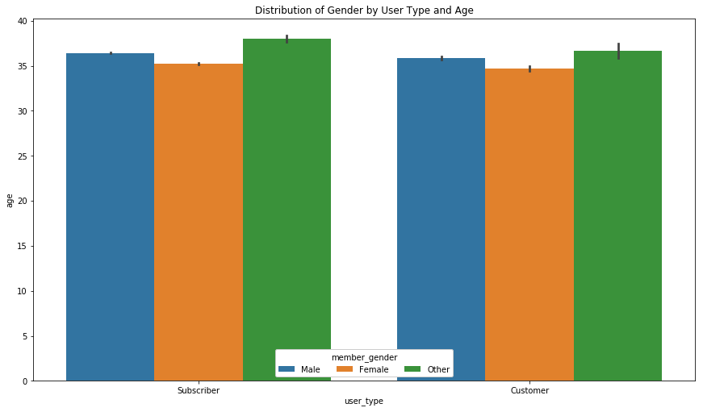

```python
myPlt("Distribution of Gender by User Type and Age", "User Type", "Age");
clusterbarplot()
```

Again you can see that both categorical variables' smallest category is showing the greatest strength when represted by age. The other-gender, customer-user portion of this dataset is showing a really interesting behavior with both `age` and `distance`. I think I'll focus on these two numerical variables from here on out.

```python
trip['distance_cat'] = trip['distance'].apply(lambda x: ((x*10//10)))
trip['distance_cat'].unique()
```

```
array([0., 2., 1., 3., 5.])
```

```python
def lineplot1():
    def mean_poly(x, y, bins = 10, **kwargs):
        """ Custom adapted line plot code. """
        # set bin edges if none or int specified
        if type(bins) == int:
            bins = np.linspace(x.min(), x.max(), bins+1)
        bin_centers = (bin_edges[1:] + bin_edges[:-1]) / 2

        # compute counts
        data_bins = pd.cut(x, bins, right = False,
                           include_lowest = True)
        means = y.groupby(data_bins).mean()

        # create plot
        plt.errorbar(x = bin_centers, y = means, **kwargs)


    bin_edges = np.arange(0.25, trip['age'].max()+ 1, 1)
    g = sb.FacetGrid(data = trip, hue = 'user_type', height = 5)
    g.map(mean_poly, "age", "distance", bins = bin_edges)
    g.set_ylabels('Distance (mi)')
    g.set_xlabels('Age')

    g.add_legend(title = 'User Type')

    g.fig.suptitle('Distribution of User Type by Age and Distance', y = 1.04)
```

```python
def facetgrid1():
    ax = sb.stripplot(data = trip.sample(trip.shape[0]//10, random_state = 42),
                 x = 'distance_cat', y = 'age', hue = 'user_type',
                 jitter = 0.035, dodge = True)
    ax.set(xlabel = 'Distance (mi)', ylabel = 'Age')
    ax.legend(['Subscriber', 'Customer'], title = 'User Type')
```

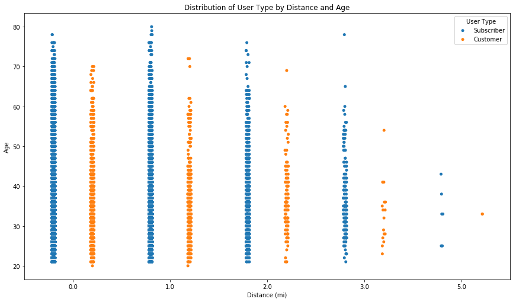

```python
myPlt("Distribution of User Type by Distance and Age", "User Type", "Age");
facetgrid1()
```

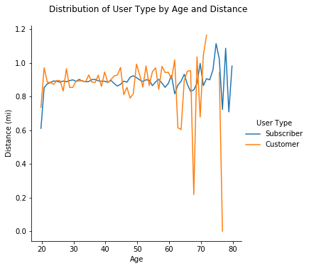

```python
lineplot1()
```

You can see here that while exploring my newly determined main numerical features (`age` and `distance`) I think it's time to figure out which of the categorical variables is most interesting when compared against the two numerical variables. This lineplot is also showing a similar relationship as the last few plots; the smaller categorical values have the highest numerical diversity. However, against `user_type`, I don't see much more to explore. So I will move on to `member_gender`.

```python
def lineplot2():
    def mean_poly(x, y, bins = 10, **kwargs):
        """ Custom adapted line plot code. """
        # set bin edges if none or int specified
        if type(bins) == int:
            bins = np.linspace(x.min(), x.max(), bins+1)
        bin_centers = (bin_edges[1:] + bin_edges[:-1]) / 2

        # compute counts
        data_bins = pd.cut(x, bins, right = False,
                           include_lowest = True)
        means = y.groupby(data_bins).mean()

        # create plot
        plt.errorbar(x = bin_centers, y = means, **kwargs)

    bin_edges = np.arange(0.25, trip['age'].max()+ 1, 1)
    g = sb.FacetGrid(data = trip, hue = 'member_gender', height = 5)
    g.map(mean_poly, "age", "distance", bins = bin_edges)
    g.set_ylabels('Distance (mi)')
    g.set_xlabels('Age')

    g.add_legend(title = 'Gender')
    g.fig.suptitle('Distribution of Gender by Age and Distance', y = 1.04)
```

```python
def facetgrid2():
    ax = sb.stripplot(data = trip.sample(trip.shape[0]//10, random_state = 42),
                 x = 'distance_cat', y = 'age', hue = 'member_gender',
                 jitter = 0.035, dodge = True)
    ax.set(xlabel = 'Distance (mi)', ylabel = 'Age')
    ax.legend(['Male', 'Female', 'Other'], title = 'Gender')
```

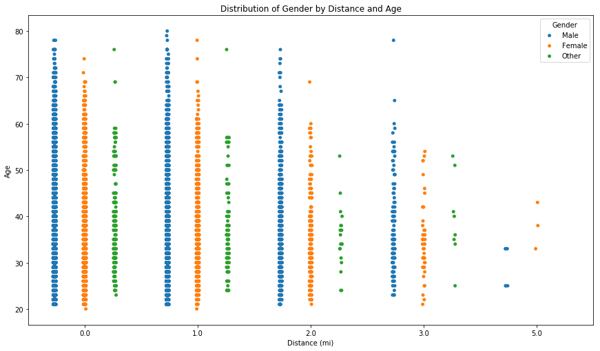

```python
myPlt("Distribution of Gender by Distance and Age", "Distance (mi)", "Age");
facetgrid2()
```

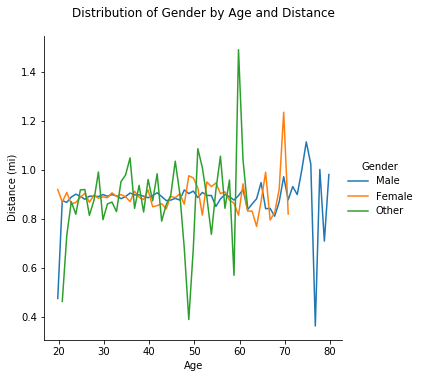

```python
lineplot2()
```

### Talk about some of the relationships you observed in this part of the investigation. Were there features that strengthened each other in terms of looking at your feature(s) of interest?

I'm sure by this point, my multivariate exploration will sort of seem like an explanatory section. For the most part... it will be. However, there are some key points I'd like to explore. Mainly the amount of members who chose not to identify (whether its in silent protest of lack of representation, or just opting out of filling out that portion for lack of personal importance) as male or female. The "other" gender type in this dataset has specifically the highest standard deviation when representing two of the numerical values, but is also the smallest category out of the `member_gender` value set. Likewise with the `user_type` value set. Though there are more Subscribers than Customers, the standard deviation when compared against two of the numerical variables.

You can see in my violinplot, that both "Customer" user type and "Other" gender type have the highest standard deviation. With wide begininnings in `age` and `distance` variables, and long tails towards the end of the plot. You can see practically the same findings in my pin, cluster bar, and line plots. Its pretty apparent that in this case, the smaller numerical variable can have the most diverse dataset.

I would say that the introduction of categorical variables to this exploration has definitely strengthened my initial univariate analysis by about 66% (mostly because when `duration_sec` is represented, it pretty much matches the very first categorical variable finding).

```python
def heatmap1():
    cat_means = trip.groupby(['user_type', 'member_gender']).mean()['duration_sec']
    cat_means = cat_means.reset_index(name = 'dur_sec_avg')
    cat_means = cat_means.pivot(index = 'member_gender', columns = 'user_type',
                                values = 'dur_sec_avg')
    ax = sb.heatmap(cat_means, annot = True, fmt = '.3f',
               cbar_kws = {'label' : 'Avr. Duration (sec)'})
    ax.set(xlabel = 'User Type', ylabel = 'Gender')
```

```python
def heatmap2():
    cat_means = trip.groupby(['user_type', 'member_gender']).mean()['age']
    cat_means = cat_means.reset_index(name = 'age_avg')
    cat_means = cat_means.pivot(index = 'member_gender', columns = 'user_type',
                                values = 'age_avg')
    ax = sb.heatmap(cat_means, annot = True, fmt = '.3f',
               cbar_kws = {'label' : 'Avr. Age'})
    ax.set(xlabel = 'User Type', ylabel = 'Gender')
```

```python
def heatmap3():
    cat_means = trip.groupby(['user_type', 'member_gender']).mean()['distance']
    cat_means = cat_means.reset_index(name = 'dis_avg')
    cat_means = cat_means.pivot(index = 'member_gender', columns = 'user_type',
                                values = 'dis_avg')
    ax = sb.heatmap(cat_means, annot = True, fmt = '.3f',
               cbar_kws = {'label' : 'Avg. Distance (mi))'})
    ax.set(xlabel = 'User Type', ylabel = 'Gender')
```

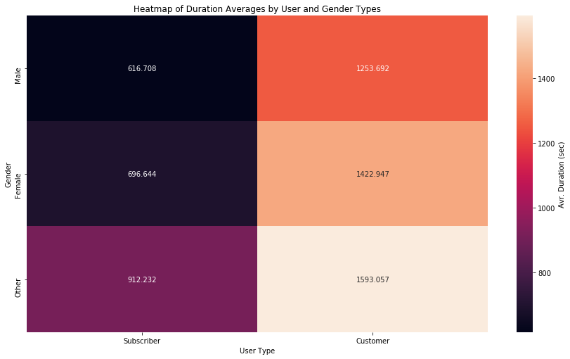

```python
myPlt("Heatmap of Duration Averages by User and Gender Types", "User Type", "Gender")
heatmap1()
```

This heatmmap and the following two heatmaps will be showing more exploration into the categorical variables relationship with each numerical by the averages of that numerical variable. Above you can see that the other-gender, customer-user group has had the highest average duration in seconds per trip. With the male subscribe having the lowest average.

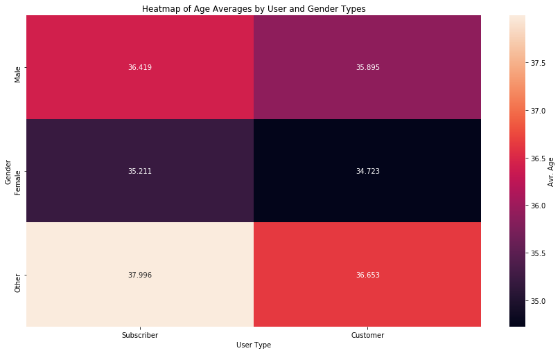

```python
myPlt("Heatmap of Age Averages by User and Gender Types", "User Type", "Gender")
heatmap2()
```

In this heatmap you can see that the highest average age belongs to the other-gender, subscriber-user group. With the lowest average in ages being the female-gender, customer-user group.

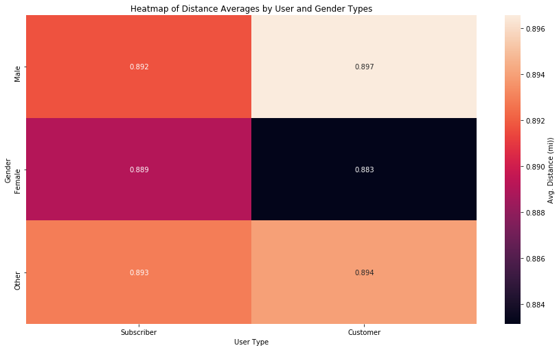

```python
myPlt("Heatmap of Distance Averages by User and Gender Types", "User Type", "Gender")
heatmap3()
```

Lastly, you can see that the highest average of distance traveled belongs to the male customer group. Whereas the lowest average in distance traveled per trip is again the female customer group. What's most interesting about the distance heatmap is that each average for each is less than a mile. I wonder how many riders use the bike share system to get to and from work.

### Polishing - User Type vs Age vs Distance

```python
def polishplot1():
    type_colors = {'Subscriber' : '#f78c00', 'Customer' : '#9400f7'}

    # plotting
    ax = sb.stripplot(data = trip.sample(trip.shape[0]//10, random_state = 42),
                 x = 'distance_cat', y = 'age', hue = 'user_type',
                 jitter = 0.035, dodge = True, palette = type_colors)
    x_ticks = [0.1, 0.2, 0.3, 0.4, 0.5, .75, 1, 2, 3, 4, 5, 6]
    ax.set(xscale = 'log')
    ax.set(xticks = x_ticks, xticklabels = x_ticks)
    ax.set(xlabel = 'Distance (mi)', ylabel = 'Age')
    ax.legend(['Subscriber', 'Customer'], title = 'User Type')
```

[figure not shown]

```python
myPlt("Age & Distance Traveled by User Type", "Distance (mi)", "Age")
polishplot1()
```

I wanted to polish up the facetgrids from earlier, just to show you how the difference in relationship strength `user_type` has vs `member_gender`. At this point, `user_type` has proven to be a bit of dead weight. Some of the information coming from its behavior when representing other variables is useful, or at least interesting. But it isn't a captivating value and thus I will not be diving further into it.

### Polishing - Member Gender vs Age vs Distance

```python
def polishplot2():
    type_colors = {'Male' : '#f70000', 'Female' : '#0008f7', 'Other' : '#198700'}

    # plotting
    ax = sb.stripplot(data = trip.sample(trip.shape[0]//10, random_state = 42),
                 x = 'distance_cat', y = 'age', hue = 'member_gender',
                 jitter = 0.035, dodge = True, palette = type_colors)
    x_ticks = [0.05, 0.1, 0.2, 0.3, 0.4, 0.5, .75, 1, 2, 3, 4, 5, 6]
    ax.set(xscale = 'log')
    ax.set(xticks = x_ticks, xticklabels = x_ticks)
    ax.set(xlabel = 'Distance (mi)', ylabel = 'Age')
    ax.legend(['Male', 'Female', 'Other'], title = 'Gender')
```

[figure not shown]

```python
myPlt("Age & Distance Traveled by Gender", "Distance (mi)", "Age")
polishplot2()
```

### Were there any interesting or surprising interactions between features?

I haven't really seen much that was entirely surprising shy of the minority values in this datasets group of categorical variables. As you can see in the heatmaps and facetgrid plots, the `Customer` member type, and the `Other` member-gender type seem to have a more diverse set of values. You can see throughout this project that both values have a much grander standard deviation than their respective counterparts. However, although I wasn't necessarily expecting this, I was ultimately not surprised.

Personally, the notion that an outlier group of variables would be more diverse than the majority set is not foreign to me.